# Titanic: an Introduction to Feature Engineering

Harry Emeric

19 October, 2017

# Introduction

This is my first attempt at Kaggle and writing a full data project. I focuss here on Feature Engineering, my next Kernel will take more of a look at the modelling and diagnostic side. Please reach out with any questions or advice, I’m here to learn and build my network.

## Loading libraries and data

```r
# Loading libraries
library(ggplot2) #charting
library(plyr) #data wrangling
library(dplyr) #data wrangling
library(Hmisc) #data wrangling
library(mice) #imputing variables
library(randomForest) #modelling
library(caret) #modelling

if(!file.exists("./TitanicTrain.csv")) {
        download.file("https://storage.googleapis.com/kaggle-competitions-data/kaggle/3136/train.csv?GoogleAccessId=competitions-data@kaggle-161607.iam.gserviceaccount.com&Expires=1508658187&Signature=WhwpAndrqdR7rqX8bgE9ynM1FPu9ihthWIMf%2Bz8ualnljh1RCDW9dLGVENX%2BdHw7YfY3jzuAV5ao4MFPzwnwkYCapqZYzAFgRqa4A%2BxIZZNjFlzocPjI6JIKxCsOw9WM7t3PahD7oZJHmVNHDan66VCx1WPb7v6t%2FiHR9LzQCFKpQbD3ceiU6bN1mT8ECmCH9gjcrgiDqGADMf0GRK%2BmsHKoTWCnnqNBh8UIi1aYFIcL3xF5SNJGC91P35lu5b8t4wSJLNuNhA05I823a3RbmoF2Rmk4LzIhm9Uv52OVXUcFG36TesdtmaJSLYCNUEYaXt9DeK%2B2vQF55BoT2YI5JQ%3D%3D","./TitanicTrain.csv",method = "curl")}

if(!file.exists("./TitanicTest.csv")) {
        download.file("https://storage.googleapis.com/kaggle-competitions-data/kaggle/3136/test.csv?GoogleAccessId=competitions-data@kaggle-161607.iam.gserviceaccount.com&Expires=1508658217&Signature=dvuLq8iI%2B5KTGzsUnkU%2Fxraxrcq197tIcGtDRAJijJhDImPrTQI0eo6ryXfd9yxcjbFr8QkXN%2FiyKKrZSfm9BVR9R%2BGpqeGZgq%2F8kdTrMc9AuDzg2HsQHTqCXrUGROpHGp7xlWo8qM160m9Rr4jG6hldzWLlmugcvN37q%2BfJYrMf0%2F9XGwDj76S6hUbgAZ6RoBOwUtBzH8CXErufmoOVpPFrZ0Ey9rSZ5jK8UCbGS58TsmkytHMZvjYdXYZGEtbeTZDzZAWap0Vqd6%2FnTgx0n35NyC1uRJ0vUzfAAb2qyvLCxr1WhVVaiLpPKkYWrOMUQyCZP6J0GHZz1GJgq1VYnA%3D%3D","./TitanicTest.csv",method = "curl")}

traindata <- read.csv("./TitanicTrain.csv",stringsAsFactors = FALSE)
testdata <- read.csv("./TitanicTest.csv",stringsAsFactors = FALSE)

c(object.size(traindata),object.size(testdata)) ## data is small so performance shouldn't be an issue
```

```
## [1] 179136  86008
```

```r
## I want to combine training and test sets because this makes it easier to perform the same
## operations on both sets

testdata$Survived <- "NA"
merged <- rbind(traindata,testdata)

length(unique(merged$PassengerId)) == length(merged$PassengerId) ## check no duped entries
```

```
## [1] TRUE
```

# Pre Clean Exploratory Data Analysis

I find it useful to guess what I think data will look like, as this gives me a benchmark to either support or attack in my initial analysis. Intuitively I would guess that anyone of higher class, either by ticket class itself or cost, would have a better chance of survival, as would women, children, and the elderly. Perhaps families too would be given a better chance of all getting into a lifeboat together as opposed to someone travelling alone?

For detailed impormation about features check here https://www.kaggle.com/c/titanic/data

```r
head(merged)
```

```
##   PassengerId Survived Pclass
## 1           1        0      3
## 2           2        1      1
## 3           3        1      3
## 4           4        1      1
## 5           5        0      3
## 6           6        0      3
##                                                  Name    Sex Age SibSp
## 1                             Braund, Mr. Owen Harris   male  22     1
## 2 Cumings, Mrs. John Bradley (Florence Briggs Thayer) female  38     1
## 3                              Heikkinen, Miss. Laina female  26     0
## 4        Futrelle, Mrs. Jacques Heath (Lily May Peel) female  35     1
## 5                            Allen, Mr. William Henry   male  35     0
## 6                                    Moran, Mr. James   male  NA     0
##   Parch           Ticket    Fare Cabin Embarked
## 1     0        A/5 21171  7.2500              S
## 2     0         PC 17599 71.2833   C85        C
## 3     0 STON/O2. 3101282  7.9250              S
## 4     0           113803 53.1000  C123        S
## 5     0           373450  8.0500              S
## 6     0           330877  8.4583              Q
```

```r
colSums(is.na(merged))
```

```
## PassengerId    Survived      Pclass        Name         Sex         Age
##           0           0           0           0           0         263
##       SibSp       Parch      Ticket        Fare       Cabin    Embarked
##           0           0           0           1           0           0
```

```r
colSums(merged=="")
```

```
## PassengerId    Survived      Pclass        Name         Sex         Age
##           0           0           0           0           0          NA
##       SibSp       Parch      Ticket        Fare       Cabin    Embarked
##           0           0           0          NA        1014           2
```

So there seems to be a lot of data missing in the Age variable and I would guess this contains a lot of information. I have seen other people trying to impute age (use the mean for example) but this is too much of a fudge for me and I’d rather train two models, one with age and one without.

Let’s look at charts of survivor trends by age, class, gender

## Class & Sex

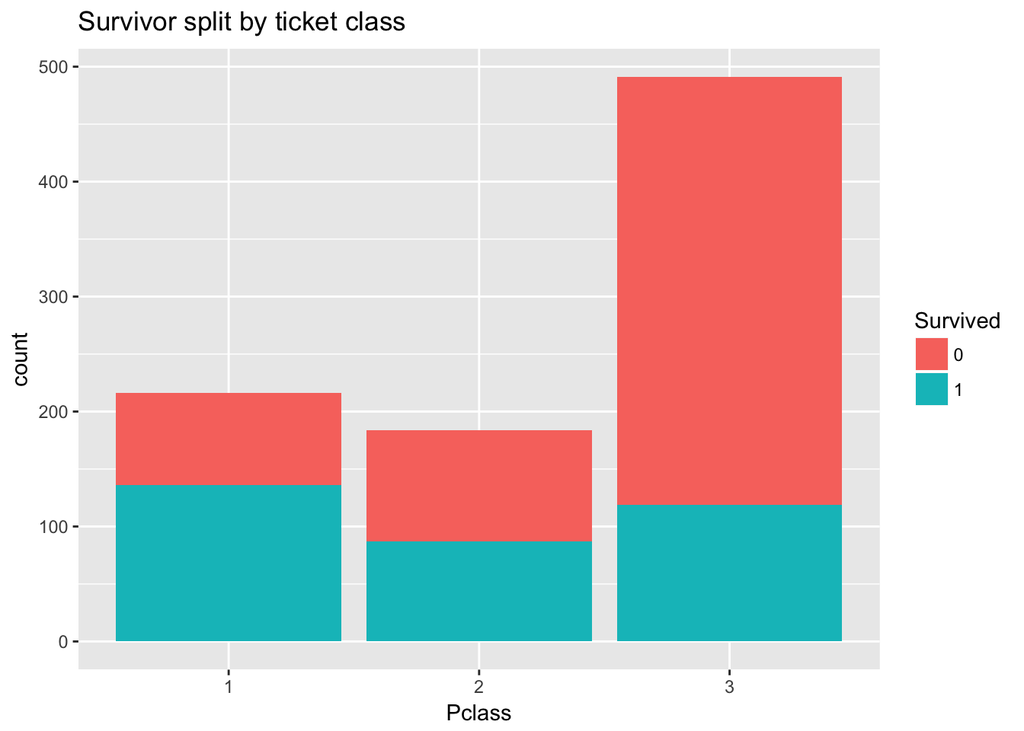

```r
merged$Pclass <- as.factor(merged$Pclass)
merged$Sex <- as.factor(merged$Sex)

g <- ggplot(merged[1:891,], aes(x=Pclass,fill=factor(Survived))) + geom_bar() + labs(fill = "Survived")
g <- g + labs(title="Survivor split by ticket class")
g
```

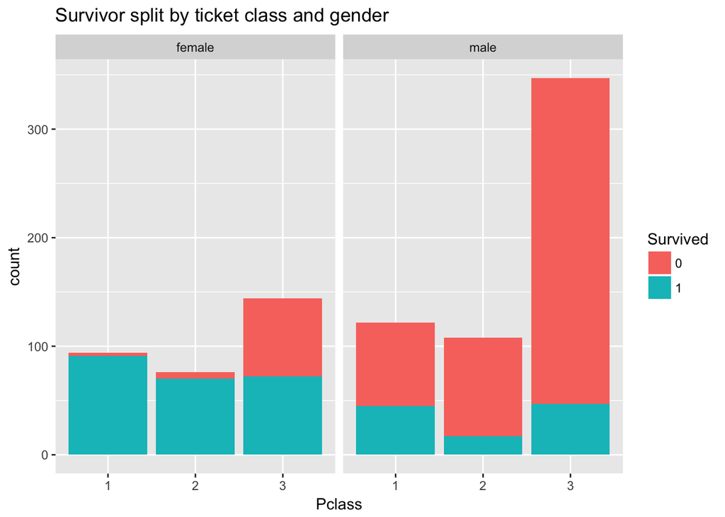

```r
g <- g + facet_wrap(~Sex) + labs(title="Survivor split by ticket class and gender")
g
```

As expected, higher class of ticket and female gender seem to be good positive predictors of survival.

## Age

I would like to segment by age and create a new feature for age bracket as having so many individual ages in the model would probably lead to overfitting.

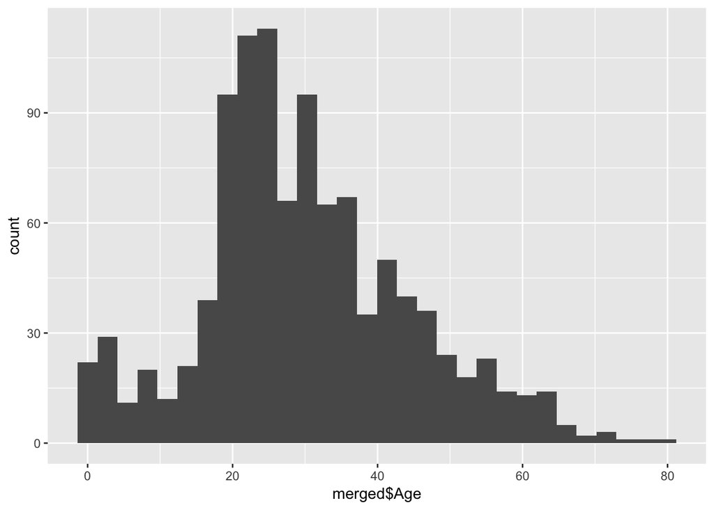

```r
qplot(merged$Age)
```

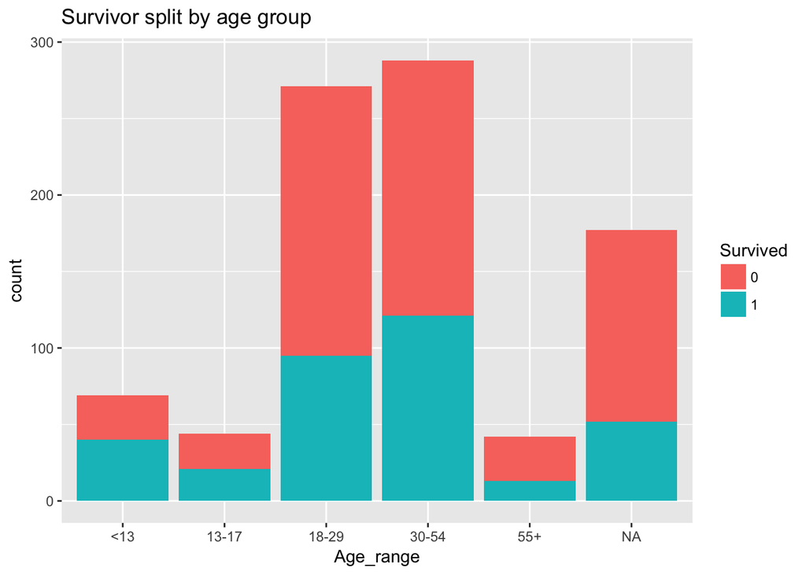

```r
agebrackets <- c(0,13,18,30,55)
merged$Agebracket <- findInterval(merged$Age,agebrackets)

agetable <- data.frame(Agebracket=c(1,2,3,4,5),Age_range=c("<13","13-17","18-29","30-54","55+"))
merged <- join(merged,agetable,by="Agebracket")
merged$Agebracket <- as.factor(merged$Agebracket)

g <- ggplot(merged[1:891,], aes(x=Age_range,fill=factor(Survived))) + geom_bar() + labs(fill = "Survived")
g <- g + labs(title="Survivor split by age group")
g
```

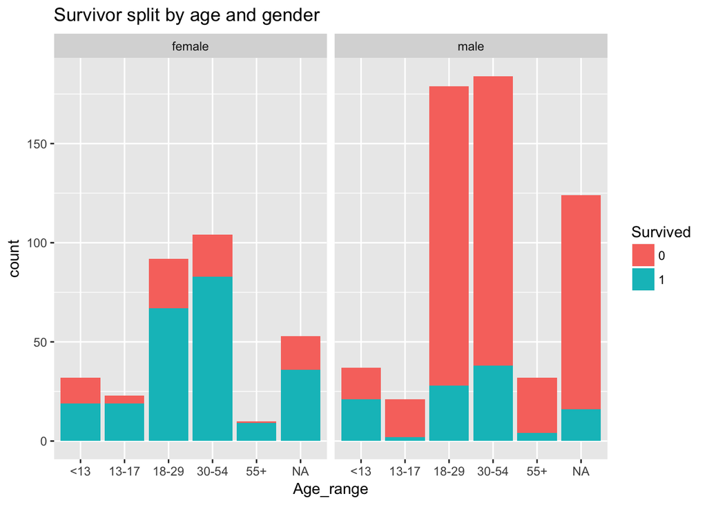

```r
g <- g + facet_wrap(~Sex) + labs(title="Survivor split by age and gender")
g
```

Age bracket seems to give a lot of information, with youger generally having a better chance of survival. Interestingly elderly women has a very good chance of survival whereas elderly men had a very bad chance so it looks like this is a useful division.

# Feature Engineering, Cleaning and Completing the Data

As discussed before I intend to split up the data into those with Age data and those without, this seems pretty central. However I want to see if this improves performance so I will do that once I’ve trained and tested a few models on the comibined set. The other variable with many missing entries is Cabin. I’m guessing this isn’t just missing data, but that a lot of people didn’t have a Cabin. So I’m thinking of turning this into a 2 factor variable, has / does not have cabin.

## Cabin

```r
head(merged$Cabin,30)
```

```
##  [1] ""            "C85"         ""            "C123"        ""
##  [6] ""            "E46"         ""            ""            ""
## [11] "G6"          "C103"        ""            ""            ""
## [16] ""            ""            ""            ""            ""
## [21] ""            "D56"         ""            "A6"          ""
## [26] ""            ""            "C23 C25 C27" ""            ""
```

```r
length(unique(merged$Cabin))/length(merged$Cabin) ## only 14% are unique so there are a lot shared.
```

```
## [1] 0.1428571
```

```r
merged$Cabin[28] # this looks strange, multiple cabins on one ticket
```

```
## [1] "C23 C25 C27"
```

```r
subset(merged,Cabin == "C23 C25 C27") # it was one family, the Fortunes
```

```
##     PassengerId Survived Pclass                                Name    Sex
## 28           28        0      1      Fortune, Mr. Charles Alexander   male
## 89           89        1      1          Fortune, Miss. Mabel Helen female
## 342         342        1      1      Fortune, Miss. Alice Elizabeth female
## 439         439        0      1                   Fortune, Mr. Mark   male
## 945         945       NA      1          Fortune, Miss. Ethel Flora female
## 961         961       NA      1 Fortune, Mrs. Mark (Mary McDougald) female
##     Age SibSp Parch Ticket Fare       Cabin Embarked Agebracket Age_range
## 28   19     3     2  19950  263 C23 C25 C27        S          3     18-29
## 89   23     3     2  19950  263 C23 C25 C27        S          3     18-29
## 342  24     3     2  19950  263 C23 C25 C27        S          3     18-29
## 439  64     1     4  19950  263 C23 C25 C27        S          5       55+
## 945  28     3     2  19950  263 C23 C25 C27        S          3     18-29
## 961  60     1     4  19950  263 C23 C25 C27        S          5       55+
```

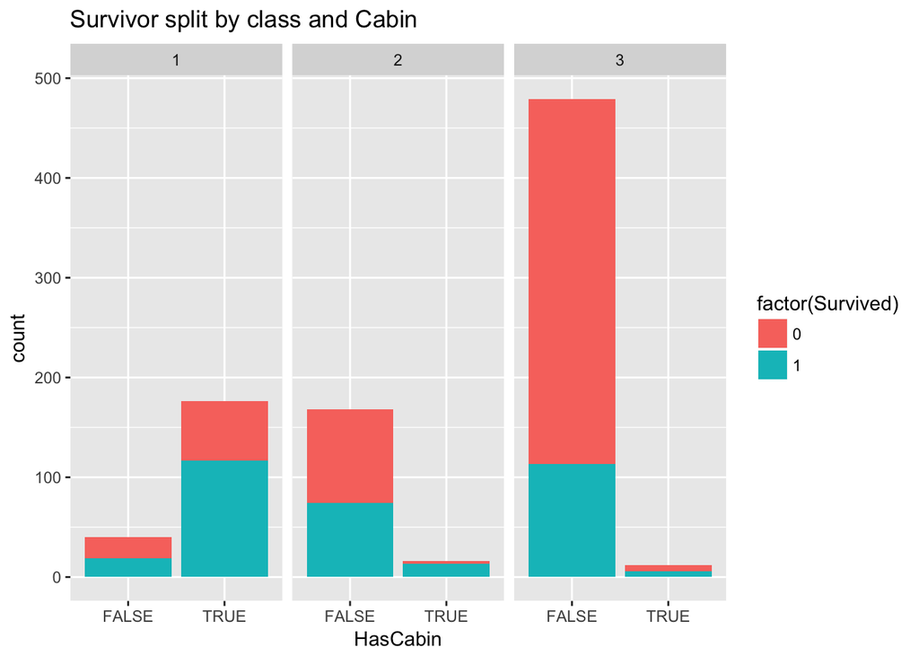

```r
merged$HasCabin <- as.factor(!(merged$Cabin==""))

g <- ggplot(merged[1:891,], aes(x=HasCabin,fill=factor(Survived))) + geom_bar()
g <- g +facet_wrap(~Pclass) + labs(title="Survivor split by class and Cabin")
g
```

As expected few people in Class 2 and 3 had cabins, but actually those who did had a good chance of survival. Helping to capture the smaller number who survived from lower classes should be very additive.

## Fare

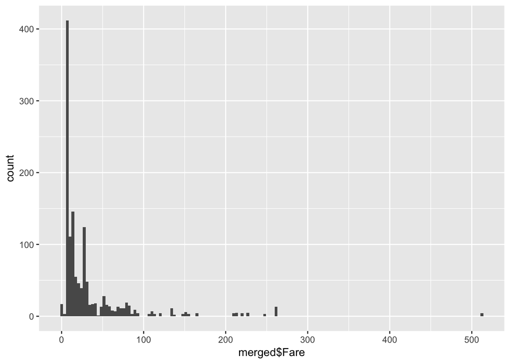

```r
qplot(merged$Fare,bins=150)
```

There doesn’t seem to be natural brackets here unlike age, so I will just split in equal groups. There is one missing entry for Fare, I will impute the average Fare for his Pclass.

```r
subset(merged,is.na(merged$Fare))
```

```
##      PassengerId Survived Pclass               Name  Sex  Age SibSp Parch
## 1044        1044       NA      3 Storey, Mr. Thomas male 60.5     0     0
##      Ticket Fare Cabin Embarked Agebracket Age_range HasCabin
## 1044   3701   NA              S          5       55+    FALSE
```

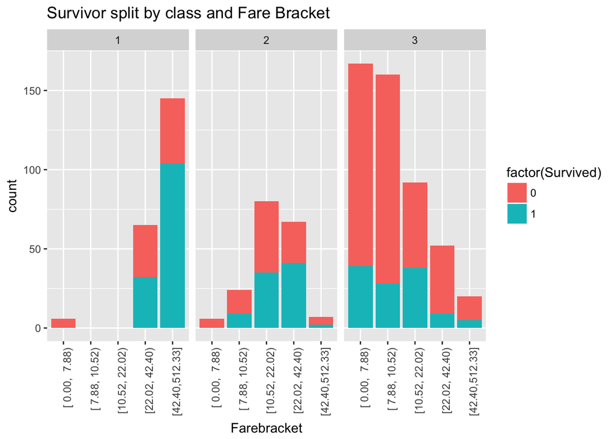

```r
merged[1044,]$Fare <- mean(subset(merged,Pclass==3)$Fare,na.rm=TRUE)

merged$Farebracket <- as.factor(cut2(merged$Fare,g=5))

g <- ggplot(merged[1:891,], aes(x=Farebracket,fill=factor(Survived))) + geom_bar()
g <- g +facet_wrap(~Pclass) + labs(title="Survivor split by class and Fare Bracket")
g <- g + theme(axis.text.x = element_text(angle = 90, hjust = 1))
g
```

```r
subset(merged,Fare==0)
```

```
##      PassengerId Survived Pclass                                  Name
## 180          180        0      3                   Leonard, Mr. Lionel
## 264          264        0      1                 Harrison, Mr. William
## 272          272        1      3          Tornquist, Mr. William Henry
## 278          278        0      2           Parkes, Mr. Francis "Frank"
## 303          303        0      3       Johnson, Mr. William Cahoone Jr
## 414          414        0      2        Cunningham, Mr. Alfred Fleming
## 467          467        0      2                 Campbell, Mr. William
## 482          482        0      2      Frost, Mr. Anthony Wood "Archie"
## 598          598        0      3                   Johnson, Mr. Alfred
## 634          634        0      1         Parr, Mr. William Henry Marsh
## 675          675        0      2            Watson, Mr. Ennis Hastings
## 733          733        0      2                  Knight, Mr. Robert J
## 807          807        0      1                Andrews, Mr. Thomas Jr
## 816          816        0      1                      Fry, Mr. Richard
```

[output cut: 39 more lines]

This is more useful than expected, it does seem to split out the survivors within a class quite nicely. There were 17 people who paid 0 fare including some in first class - I don’t think its worth creating a separate category here though.

One group paid over $500! But is ticket overall cost or each ticket?

```r
head(order(merged$Fare,decreasing = TRUE))
```

```
## [1]  259  680  738 1235   28   89
```

```r
merged[259,]
```

```
##     PassengerId Survived Pclass             Name    Sex Age SibSp Parch
## 259         259        1      1 Ward, Miss. Anna female  35     0     0
##       Ticket     Fare Cabin Embarked Agebracket Age_range HasCabin
## 259 PC 17755 512.3292              C          4     30-54    FALSE
##        Farebracket
## 259 [42.40,512.33]
```

```r
subset(merged,Fare==merged$Fare[259])
```

```
##      PassengerId Survived Pclass
## 259          259        1      1
## 680          680        1      1
## 738          738        1      1
## 1235        1235       NA      1
##                                                                 Name
## 259                                                 Ward, Miss. Anna
## 680                               Cardeza, Mr. Thomas Drake Martinez
## 738                                           Lesurer, Mr. Gustave J
## 1235 Cardeza, Mrs. James Warburton Martinez (Charlotte Wardle Drake)
##         Sex Age SibSp Parch   Ticket     Fare       Cabin Embarked
## 259  female  35     0     0 PC 17755 512.3292                    C
## 680    male  36     0     1 PC 17755 512.3292 B51 B53 B55        C
## 738    male  35     0     0 PC 17755 512.3292        B101        C
## 1235 female  58     0     1 PC 17755 512.3292 B51 B53 B55        C
##      Agebracket Age_range HasCabin    Farebracket
## 259           4     30-54    FALSE [42.40,512.33]
## 680           4     30-54     TRUE [42.40,512.33]
## 738           4     30-54     TRUE [42.40,512.33]
## 1235          5       55+     TRUE [42.40,512.33]
```

Just for fun: from https://en.wikipedia.org/wiki/Titanic_(1997_film) Jack Dawson is actually Joseph Dawson, who is not in our sample, and neither is Rose. I didn’t need a model to classify them anyway.

```r
grep("Dawson",merged$Name)
```

```
## integer(0)
```

```r
merged[grep("Rose",merged$Name),]
```

```
##      PassengerId Survived Pclass
## 856          856        1      3
## 1100        1100       NA      1
## 1219        1219       NA      1
##                                             Name    Sex Age SibSp Parch
## 856                   Aks, Mrs. Sam (Leah Rosen) female  18     0     1
## 1100               Rosenbaum, Miss. Edith Louise female  33     0     0
## 1219 Rosenshine, Mr. George (Mr George Thorne")"   male  46     0     0
##        Ticket    Fare Cabin Embarked Agebracket Age_range HasCabin
## 856    392091  9.3500              S          3     18-29    FALSE
## 1100 PC 17613 27.7208   A11        C          4     30-54     TRUE
## 1219 PC 17585 79.2000              C          4     30-54    FALSE
##         Farebracket
## 856  [ 7.88, 10.52)
## 1100 [22.02, 42.40)
## 1219 [42.40,512.33]
```

## Title

```r
merged$Title <- gsub('(.*, )|(\\..*)', '', merged$Name)

count(merged,Title)
```

```
## # A tibble: 18 x 2
##           Title     n
##           <chr> <int>
##  1         Capt     1
##  2          Col     4
##  3          Don     1
##  4         Dona     1
##  5           Dr     8
##  6     Jonkheer     1
##  7         Lady     1
##  8        Major     2
##  9       Master    61
## 10         Miss   260
## 11         Mlle     2
## 12          Mme     1
## 13           Mr   757
## 14          Mrs   197
## 15           Ms     2
## 16          Rev     8
## 17          Sir     1
## 18 the Countess     1
```

```r
VIP <- c("Capt","Col","Don","Dona","Dr","Jonkheer","Lady","Major",
         "Mlle", "Mme","Rev","Sir","the Countess")

merged$Title[merged$Title %in% VIP] <- "VIP"
merged$Title <- as.factor(merged$Title)

count(merged,Title)
```

```
## # A tibble: 6 x 2
##    Title     n
##   <fctr> <int>
## 1 Master    61
## 2   Miss   260
## 3     Mr   757
## 4    Mrs   197
## 5     Ms     2
## 6    VIP    32
```

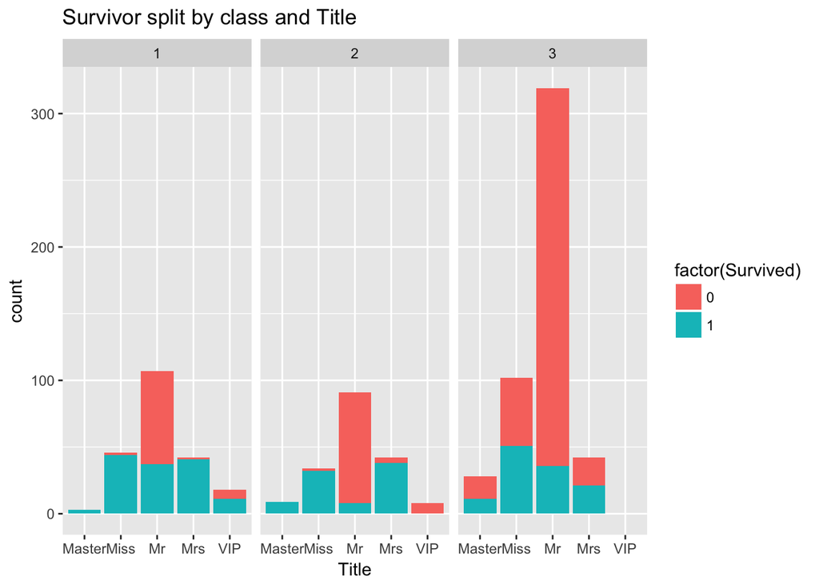

```r
## I'm not that keen on only having 2 in the "Ms" camp
merged[merged$Title=="Ms",]$Title <- "Mrs"

g <- ggplot(merged[1:891,], aes(x=Title,fill=factor(Survived))) + geom_bar()
g <- g +facet_wrap(~Pclass) + labs(title="Survivor split by class and Title")
g
```

I’m not sure how useful this is going to be based on the charts.

## Name

Onto surname, I’m interested to see if there was some racial bias here.

```r
library(wru) # who r u - library to guess race from surname

merged$surname<- gsub("([A-Za-z]+).*", "\\1", merged$Name)

raceprobs <- predict_race(merged,surname.only = TRUE)
```

```
## [1] "Proceeding with surname-only predictions..."
```

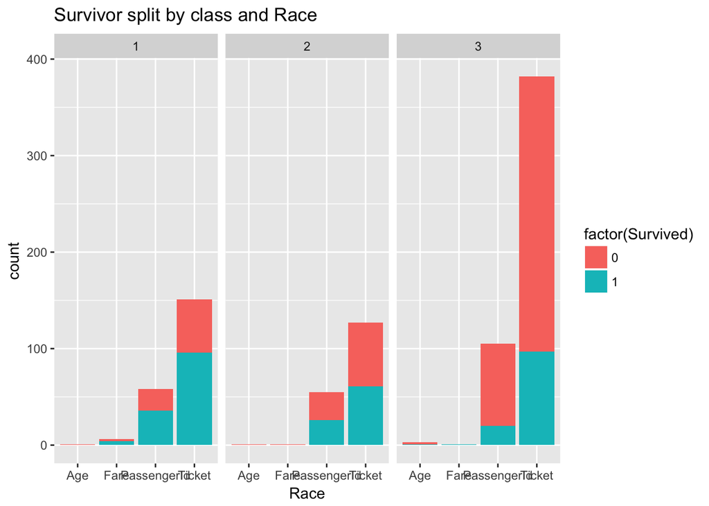

```r
racepreds <- suppressWarnings(colnames(raceprobs)[apply(raceprobs,1,which.max)])
merged$Race <- as.factor(sub('.*\\.', '',racepreds))

g <- ggplot(merged[1:891,], aes(x=Race,fill=factor(Survived))) + geom_bar()
g <- g +facet_wrap(~Pclass) + labs(title="Survivor split by class and Race")
g
```

## Ticketsize variable

Create a variable for number of people on a single tickt to give a count for group size.

```r
merged <- ddply(merged,.(Ticket),transform,Ticketsize=length(Ticket))
merged$Ticketsize <- as.factor(merged$Ticketsize)
merged <- merged[order(merged$PassengerId),] # ddply mixes up order
```

## Embarked

Move the two cases where this is unmarked to the modal case, “S”

```r
count(merged,Embarked)
```

```
## # A tibble: 4 x 2
##   Embarked     n
##      <chr> <int>
## 1              2
## 2        C   270
## 3        Q   123
## 4        S   914
```

```r
subset(merged,Embarked == "")
```

```
##    PassengerId Survived Pclass                                      Name
## 59          62        1      1                       Icard, Miss. Amelie
## 60         830        1      1 Stone, Mrs. George Nelson (Martha Evelyn)
##       Sex Age SibSp Parch Ticket Fare Cabin Embarked Agebracket Age_range
## 59 female  38     0     0 113572   80   B28                   4     30-54
## 60 female  62     0     0 113572   80   B28                   5       55+
##    HasCabin    Farebracket Title surname   Race Ticketsize
## 59     TRUE [42.40,512.33]  Miss   Icard Ticket          2
## 60     TRUE [42.40,512.33]   Mrs   Stone Ticket          2
```

```r
merged[c(62,830),"Embarked"] <- "S"
merged$Embarked <- as.factor(merged$Embarked)
```

## Age

To begin with, I want to use the mice library to impute the missing ages. Then I want to check if we get improvement by splitting data as explained above; this seems pivtotal to the analysis.

```r
factors <- c("Pclass","Sex","Agebracket","Title")
set.seed(1234)

m1 <- merged[, !names(merged) %in% c("Agebracket","Age_range")]
mice_ages <- mice(m1[, !names(m1) %in% factors], method='rf')
mice_out <- complete(mice_ages)

# I am creating a new variable for the imputed ages because I want to later compare to
# training a model both for entries with and without ages.
```

```r
mergedages <- merged[,!names(merged) == "Age_range"]
mergedages$Age <- mice_out$Age

mergedages$Agebracket <- findInterval(mergedages$Age,agebrackets)
mergedages <- join(mergedages,agetable,by="Agebracket")
mergedages$Agebracket <- as.factor(mergedages$Agebracket)

colSums(is.na(mergedages))
```

```
## PassengerId    Survived      Pclass        Name         Sex         Age
##           0           0           0           0           0           0
##       SibSp       Parch      Ticket        Fare       Cabin    Embarked
##           0           0           0           0           0           0
##  Agebracket    HasCabin Farebracket       Title     surname        Race
##           0           0           0           0           0           0
##  Ticketsize   Age_range
##           0           0
```

```r
colSums(mergedages=="")
```

```
## PassengerId    Survived      Pclass        Name         Sex         Age
##           0           0           0           0           0           0
##       SibSp       Parch      Ticket        Fare       Cabin    Embarked
##           0           0           0           0        1014           0
##  Agebracket    HasCabin Farebracket       Title     surname        Race
##           0           0           0           0           0           0
##  Ticketsize   Age_range
##           0           0
```

We are ready to start fitting some models!

# Model Fitting

First split the data back into training/ CV and set we use for submission,

```r
mergedagestrain <- mergedages[1:891,]
mergedagestest <- mergedages[892:1309,]
mergedagestrain$Survived <- as.factor(traindata$Survived)

set.seed(414)
inTrain<- createDataPartition(y=mergedagestrain$Survived,p=0.75, list=FALSE)
train <- mergedagestrain[inTrain,]
test <- mergedagestrain[-inTrain,]
```

## Logistic Regression

```r
set.seed(414)
logreg <- glm(Survived ~ Pclass + Sex + Agebracket +
                      Farebracket + HasCabin + Ticketsize
               + Title + Embarked, family = binomial(link=logit),
              data = train)

summary(logreg)
```

```
##
## Call:
## glm(formula = Survived ~ Pclass + Sex + Agebracket + Farebracket +
##     HasCabin + Ticketsize + Title + Embarked, family = binomial(link = logit),
##     data = train)
##
## Deviance Residuals:
##     Min       1Q   Median       3Q      Max
## -2.0489  -0.5243  -0.3232   0.5209   2.5095
##
## Coefficients:
##                             Estimate Std. Error z value Pr(>|z|)
## (Intercept)                 19.76557 1693.82282   0.012 0.990690
## Pclass2                     -0.27739    0.63383  -0.438 0.661650
## Pclass3                     -1.46722    0.71995  -2.038 0.041555 *
## Sexmale                    -16.92374 1693.82253  -0.010 0.992028
## Agebracket2                 -0.03932    0.72779  -0.054 0.956916
## Agebracket3                 -0.19908    0.59010  -0.337 0.735845
## Agebracket4                 -0.56536    0.60127  -0.940 0.347070
## Agebracket5                 -0.97371    0.76163  -1.278 0.201092
## Farebracket[ 7.88, 10.52)    0.11397    0.40209   0.283 0.776839
## Farebracket[10.52, 22.02)   -0.06481    0.46795  -0.139 0.889839
## Farebracket[22.02, 42.40)   -0.01954    0.58383  -0.033 0.973298
## Farebracket[42.40,512.33]    0.29059    0.90885   0.320 0.749170
## HasCabinTRUE                 1.19256    0.45214   2.638 0.008349 **
## Ticketsize2                 -0.38748    0.44680  -0.867 0.385806
## Ticketsize3                  0.20274    0.55375   0.366 0.714274
## Ticketsize4                  0.51410    0.67960   0.756 0.449365
## Ticketsize5                 -2.36198    0.87536  -2.698 0.006970 **
## Ticketsize6                 -3.26344    0.92619  -3.524 0.000426 ***
## Ticketsize7                 -1.95485    0.97908  -1.997 0.045867 *
## Ticketsize8                 -0.72182    1.57112  -0.459 0.645927
## Ticketsize11               -15.91704  883.98003  -0.018 0.985634
## TitleMiss                  -17.23174 1693.82266  -0.010 0.991883
## TitleMr                     -3.33835    0.73579  -4.537  5.7e-06 ***
## TitleMrs                   -16.53915 1693.82271  -0.010 0.992209
## TitleVIP                    -3.94466    1.10430  -3.572 0.000354 ***
## EmbarkedQ                    0.08487    0.50003   0.170 0.865225
## EmbarkedS                   -0.51087    0.31739  -1.610 0.107485
## ---
## Signif. codes:  0 '***' 0.001 '**' 0.01 '*' 0.05 '.' 0.1 ' ' 1
##
## (Dispersion parameter for binomial family taken to be 1)
##
##     Null deviance: 891.19  on 668  degrees of freedom
## Residual deviance: 514.07  on 642  degrees of freedom
## AIC: 568.07
##
## Number of Fisher Scoring iterations: 15
```

```r
prediction <- predict(logreg,newdata=test,type="response")
prediction <- ifelse(prediction > 0.5,1,0)
misClasificError <- mean(prediction != test$Survived)
print(paste('Accuracy',1-misClasificError)) ## Accuracy 81%
```

```
## [1] "Accuracy 0.810810810810811"
```

## Regularised Logistic Regression using lasso

Let’s see if we can improve the model using lasso regularisation

```r
set.seed(414)
library(glmnet)
x <- model.matrix(Survived ~ Pclass + Sex + Farebracket + HasCabin + Ticketsize + Embarked + Title,train)
cv.out <- cv.glmnet(x,y=train$Survived,alpha=1,family="binomial",type.measure = "mse") #select lambda -4

#best value of lambda
lambda_1se <- cv.out$lambda.1se

xtest <- model.matrix(Survived ~ Pclass + Sex + Farebracket + HasCabin + Ticketsize + Embarked + Title,test)
lasso_prob <- predict(cv.out,newx = xtest,s=lambda_1se,type="response")
#translate probabilities to predictions

lasso_predict <- rep("0",nrow(test))
lasso_predict[lasso_prob>.5] <-"1"
#confusion matrix
table(pred=lasso_predict,true=test$Survived)
```

```
##     true
## pred   0   1
##    0 117  20
##    1  20  65
```

```r
mean(lasso_predict==test$Survived) #82% accuracy
```

```
## [1] 0.8198198
```

## Random Forest

```r
set.seed(414)
rf_model <- randomForest(factor(Survived) ~ Pclass + Sex + Agebracket +
                                 Farebracket + Race + HasCabin + Ticketsize +
                                 Embarked + Title,
                         data = mergedagestrain,na.action = na.pass)

rf_model
```

```
##
## Call:
##  randomForest(formula = factor(Survived) ~ Pclass + Sex + Agebracket +      Farebracket + Race + HasCabin + Ticketsize + Embarked + Title,      data = mergedagestrain, na.action = na.pass)
##                Type of random forest: classification
##                      Number of trees: 500
## No. of variables tried at each split: 3
##
##         OOB estimate of  error rate: 16.61%
## Confusion matrix:
##     0   1 class.error
## 0 492  57   0.1038251
## 1  91 251   0.2660819
```

```r
rf_model$confusion
```

```
##     0   1 class.error
## 0 492  57   0.1038251
## 1  91 251   0.2660819
```

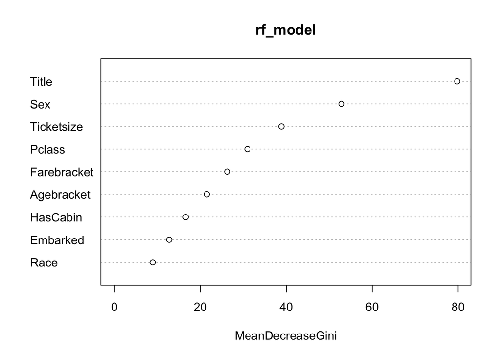

```r
varImpPlot(rf_model)
```

```r
importance(rf_model)
```

```
##             MeanDecreaseGini
## Pclass             30.940897
## Sex                52.825212
## Agebracket         21.484458
## Farebracket        26.239919
## Race                8.875329
## HasCabin           16.581731
## Ticketsize         38.851299
## Embarked           12.723345
## Title              79.780388
```

```r
set.seed(414)
rf_model2 <- randomForest(factor(Survived) ~ Pclass + Sex + Farebracket + HasCabin + Ticketsize + Embarked + Title,
                         data = mergedagestrain,na.action = na.pass,nodesize=20)

rf_model2 #looks the best
```

```
##
## Call:
##  randomForest(formula = factor(Survived) ~ Pclass + Sex + Farebracket +      HasCabin + Ticketsize + Embarked + Title, data = mergedagestrain,      nodesize = 20, na.action = na.pass)
##                Type of random forest: classification
##                      Number of trees: 500
## No. of variables tried at each split: 2
##
##         OOB estimate of  error rate: 16.27%
## Confusion matrix:
##     0   1 class.error
## 0 501  48  0.08743169
## 1  97 245  0.28362573
```

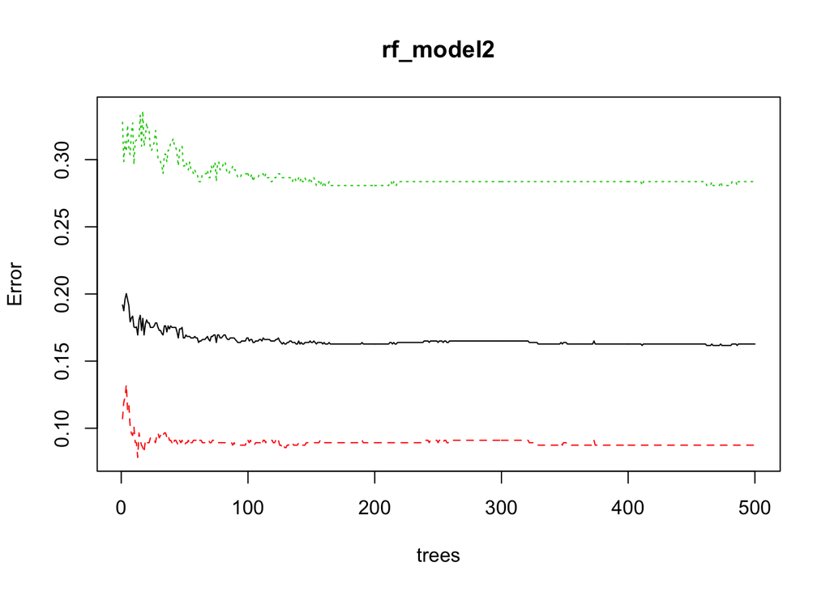

```r
plot(rf_model2)
```

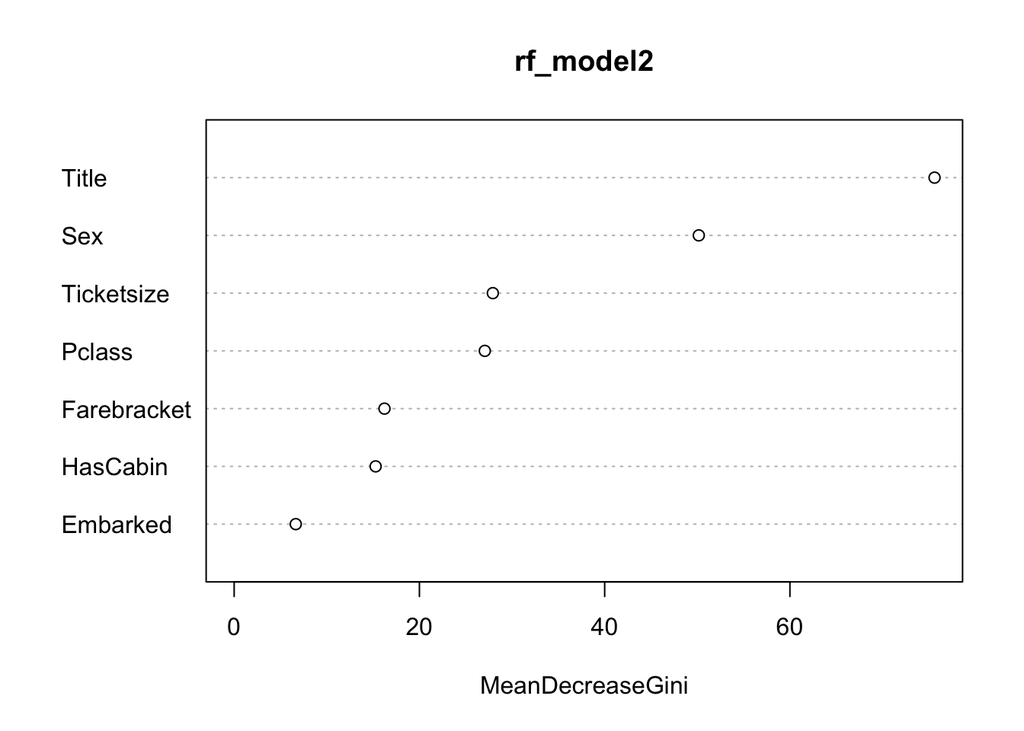

```r
varImpPlot(rf_model2)
```

```r
importance(rf_model2)
```

```
##             MeanDecreaseGini
## Pclass             27.060232
## Sex                50.163080
## Farebracket        16.228239
## HasCabin           15.272008
## Ticketsize         27.926492
## Embarked            6.651349
## Title              75.613812
```

## GBM

```r
features <- c("Survived","Pclass","Sex","SibSp","Parch","HasCabin","Farebracket","Title","Ticketsize","Age_range")
fitControl <- trainControl(method = "repeatedcv", number = 4, repeats = 4)

set.seed(414)
gbm1 <- suppressWarnings(train(as.factor(Survived) ~ ., data = train[features],
              method = "gbm", trControl = fitControl,verbose = FALSE))
prediction <- predict(gbm1, test[features],type= "prob")
prediction <- data.frame(ifelse(prediction[,2] > 0.5,1,0))
mean(prediction[,1] == test$Survived) #83% accuracy
```

```
## [1] 0.8333333
```

```r
set.seed(414)
fitControl2 <- trainControl(method = "repeatedcv", number = 6, repeats = 4)
gbm2 <- suppressWarnings(train(as.factor(Survived) ~ ., data = train[features],
              method = "gbm", trControl = fitControl,verbose = FALSE))
prediction <- predict(gbm2, test[features],type= "prob")
prediction <- data.frame(ifelse(prediction[,2] > 0.5,1,0))
mean(prediction[,1] == test$Survived) #83% accuracy
```

```
## [1] 0.8333333
```

## Splitting models depending on whether age is available or not

```r
row.names(merged) <- merged$PassengerId
mergedtrain <- merged[1:891,]
mergedtest <- merged[892:1309,]
mergedtrain$Survived <- as.factor(mergedtrain$Survived)

sum(is.na(mergedtrain$Age))
```

```
## [1] 177
```

```r
sum(is.na(mergedtest$Age))
```

```
## [1] 86
```

```r
rf_model_ages <- randomForest(factor(Survived) ~ Pclass + Sex + Farebracket + HasCabin + Agebracket + Ticketsize + Embarked + Title,
                              data = mergedtrain[!is.na(mergedtrain$Age),],nodesize=20)

rf_model_ages
```

```
##
## Call:
##  randomForest(formula = factor(Survived) ~ Pclass + Sex + Farebracket +      HasCabin + Agebracket + Ticketsize + Embarked + Title, data = mergedtrain[!is.na(mergedtrain$Age),      ], nodesize = 20)
##                Type of random forest: classification
##                      Number of trees: 500
## No. of variables tried at each split: 2
##
##         OOB estimate of  error rate: 17.51%
## Confusion matrix:
##     0   1 class.error
## 0 386  38  0.08962264
## 1  87 203  0.30000000
```

```r
rf_model_ages$confusion
```

```
##     0   1 class.error
## 0 386  38  0.08962264
## 1  87 203  0.30000000
```

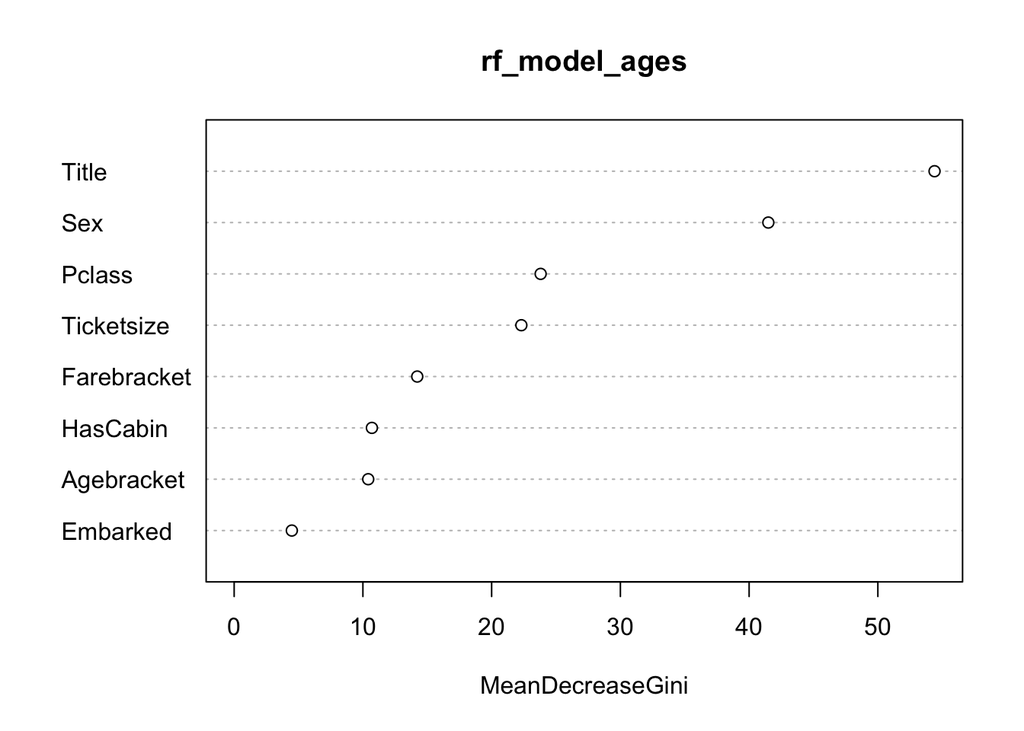

```r
varImpPlot(rf_model_ages)
```

```r
importance(rf_model_ages)
```

```
##             MeanDecreaseGini
## Pclass             23.806304
## Sex                41.491606
## Farebracket        14.220238
## HasCabin           10.698976
## Agebracket         10.412179
## Ticketsize         22.307165
## Embarked            4.478362
## Title              54.402836
```

```r
rf_model_noages <- randomForest(factor(Survived) ~ Pclass + Sex +
                                      Farebracket + Race + HasCabin + Ticketsize +
                                      Embarked + Title,
                              data = mergedtrain[is.na(mergedtrain$Age),],nodesize=20)

rf_model_noages
```

```
##
## Call:
##  randomForest(formula = factor(Survived) ~ Pclass + Sex + Farebracket +      Race + HasCabin + Ticketsize + Embarked + Title, data = mergedtrain[is.na(mergedtrain$Age),      ], nodesize = 20)
##                Type of random forest: classification
##                      Number of trees: 500
## No. of variables tried at each split: 2
##
##         OOB estimate of  error rate: 13.56%
## Confusion matrix:
##     0  1 class.error
## 0 117  8   0.0640000
## 1  16 36   0.3076923
```

```r
rf_model_noages$confusion
```

```
##     0  1 class.error
## 0 117  8   0.0640000
## 1  16 36   0.3076923
```

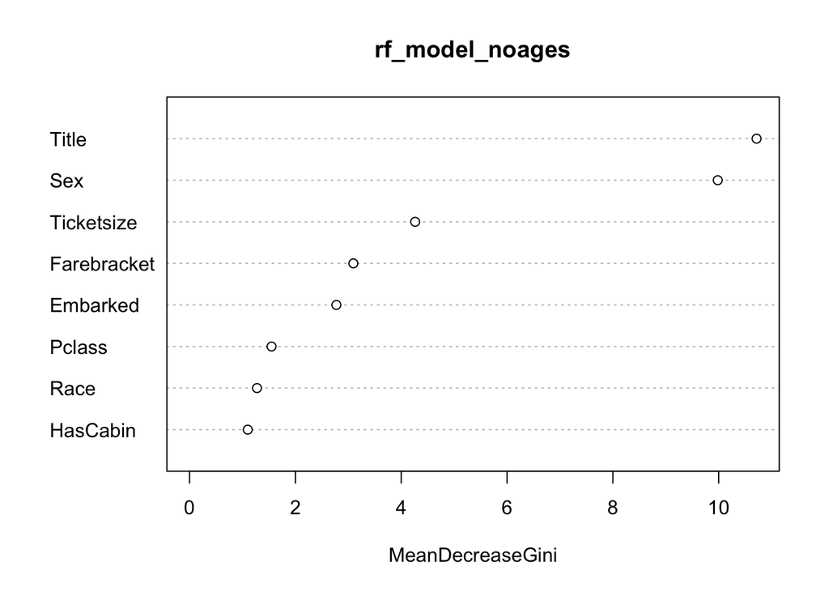

```r
varImpPlot(rf_model_noages)
```

```r
importance(rf_model_noages)
```

```
##             MeanDecreaseGini
## Pclass              1.549449
## Sex                 9.982232
## Farebracket         3.094999
## Race                1.273963
## HasCabin            1.099430
## Ticketsize          4.263085
## Embarked            2.774638
## Title              10.715808
```

```r
p1 <- predict(rf_model_ages, mergedtest[!is.na(mergedtest$Age),])
p2 <- predict(rf_model_noages, mergedtest[is.na(mergedtest$Age),])
prediction <- join(data.frame(PassengerId=names(p1),Survived=p1),data.frame(PassengerId=names(p2),Survived=p2))
# This actually didn't help my position on the leaderboard, pretty surprised by this
```

# Evaluation and submission

The model rf2 looks the best so I will submit that.

```r
prediction <- predict(rf_model2, mergedagestest)
submission <- data.frame(PassengerId=names(prediction),Survived=prediction)
if(!file.exists("./predictions.csv")) {
        write.csv(submission, file = "./predictions.csv",row.names = F)}
```

This submission got me into the top 6% which I was very pleased with for my first attempt.

For my next project I want to take a more purposeful approach to model selection, with a more extensive evaluation and diagnostics for parameter tuning. I also want to work on seeing how feature engineering and model selection work in concert with each other.

Thanks for reading, if you’ve got this far surely its worth an upvote :)